# A TIME SERIES INVESTIGATION OF HARMFUL AIR POLLUTANTS CONCENTRATIONS IN BERLIN

# Correlation Matrix

> A dataframe is created with the values of NO2,O3,NO . The correlation matrix is created for the three pollutants using the melt() and visualized using the heatmap

```r
# Creating a data frame with the three pollutants
pollutants_df <- data.frame(Nitrogen_dioxide, Ozone, Nitrogen_Monoxide)

# calculation of the correlation matrix
cor_matrix <- cor(pollutants_df)
cor_matrix
```

```
##                   Nitrogen_dioxide      Ozone Nitrogen_Monoxide
## Nitrogen_dioxide         1.0000000 -0.6790400         0.9321533
## Ozone                   -0.6790400  1.0000000        -0.7492595
## Nitrogen_Monoxide        0.9321533 -0.7492595         1.0000000
```

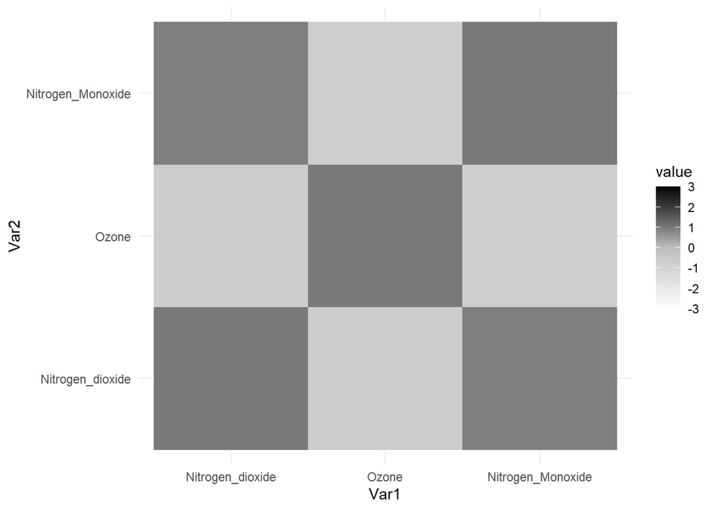

```r
#Visualizing the correlation matrix
cor_df <- melt(cor_matrix)


# creation of a heatmap
ggplot(cor_df, aes(x = Var1, y = Var2, fill = value)) +
  geom_tile() +
  scale_fill_gradient2(low = "white", mid = "grey", high = "black",
                       midpoint = 0, limit = c(-3,3)) +
  theme_minimal() +
  theme(axis.text.x = element_text(angle = 0))
```

# Results :

> The air quality standard set by the European Union for NO2 on annual mean basis is 40 ug/m3. From the time series plot measured it can be seen that the NO2 values are under the threshold and comply within the EU standards making the air quality much better and sustainable.

> The correlation matrix results that the Pollutant NO2 is positively high correlated with NO and is negatively correlated with O3 and Ozone is negatively correlated with NO

# Conclusion and Discussion :

> The NO2 levels are well under the standard in this station suggesting that this part of the city is well formed and adapted.

> The Ozone levels influenced by the weather conditions suggest that they are to be monitored at a greater level for changes. Sudden increase in their levels are not because of the direct emission indicating that they need to be monitored at a higher temporal scale.

# References:

> https://environment.ec.europa.eu/topics/air/air-quality/eu-air-quality-standards_en

> Kurtenbach, R., Kleffmann, J., Niedojadlo, A. et al. Primary NO2 emissions and their impact on air quality in traffic environments in Germany. Environ Sci Eur 24, 21 (2012)

> Hagenbjörk, A., Malmqvist, E., Mattisson, K. et al. The spatial variation of O3, NO, NO2 and NO x and the relation between them in two Swedish cities. Environ Monit Assess 189, 161 (2017).

> https://r-spatial.org/book/12-Interpolation.html